# Handling Large Datasets in R

Somnath Chaudhuri, University of Southampton, UK

February 08, 2026

# Introduction to Handling Large Datasets in R

## Welcome to the Big Data Analysis and Management Training Program

Welcome to the second section of our comprehensive training program! This section focuses on **handling large datasets in R**. In today’s data‑driven world, working with large datasets is a common requirement for analysts, researchers, and data scientists. This manual guides you through practical techniques to handle datasets that don’t fit comfortably in memory or require efficient processing.

**Learning goals** - Understand and manage memory constraints when working with large datasets - Use **data.table** for high‑speed, memory‑efficient data manipulation - Apply memory‑aware techniques using **dplyr**/**tidyverse** - Implement **chunk processing** for extremely large files - Benchmark and compare approaches for speed and memory - Apply **best practices** for big‑data handling in R

> **Tip for knitting**: Some operations (e.g., writing multi‑GB CSVs) can be time‑consuming. Where appropriate, heavy chunks are set to `eval=FALSE` with clear instructions—run interactively when needed.

# 1. Creating and Understanding Large Datasets

**What you’ll do**: Create a realistic 1‑million‑row dataset and explore its structure and memory footprint.

## 1.1 Creating a Large Sample Dataset

The training dataset simulates customer/employee‑like records: 1) **ID** – unique identifier  
2) **Age** – 18–65 years  
3) **Income** – annual income (normal distribution)  
4) **Education** – High School / Bachelor / Master / PhD  
5) **Score** – performance score (50–100)

```r
set.seed(123)

# Define dataset size
n <- 1000000  # 1 million rows

# Create the dataset
large_data <- data.frame(
  ID = 1:n,
  Age = sample(18:65, n, replace = TRUE),
  Income = round(rnorm(n, mean = 50000, sd = 15000), 0),
  Education = sample(c("High School", "Bachelor", "Master", "PhD"),
                     n, replace = TRUE, prob = c(0.3, 0.4, 0.2, 0.1)),
  Score = round(runif(n, min = 50, max = 100), 1)
)

# Quick confirmation
list(rows = nrow(large_data), cols = ncol(large_data), columns = names(large_data))
```

```
## $rows
## [1] 1000000
##
## $cols
## [1] 5
##
## $columns
## [1] "ID"        "Age"       "Income"    "Education" "Score"
```

## 1.2 Understanding Dataset Structure

**Instructions**: Inspect dimensions, column names, head/tail, and types. Use `str()` for an at‑a‑glance structure.

```r
info <- list(
  Dimensions = dim(large_data),
  Column_Names = names(large_data)
)
info
```

```
## $Dimensions
## [1] 1000000       5
##
## $Column_Names
## [1] "ID"        "Age"       "Income"    "Education" "Score"
```

```r
head(large_data, 5)
```

```
##   ID Age Income   Education Score
## 1  1  48  79566    Bachelor  70.7
## 2  2  32  56808      Master  58.9
## 3  3  31  49234    Bachelor  66.0
## 4  4  20  68092      Master  51.9
## 5  5  59  31843 High School  89.0
```

```r
tail(large_data, 5)
```

```
##              ID Age Income   Education Score
## 999996   999996  59  45904         PhD  59.6
## 999997   999997  32  36070      Master  59.7
## 999998   999998  46  34410         PhD  70.5
## 999999   999999  58  48910 High School  84.9
## 1000000 1000000  55  74036      Master  50.8
```

```r
str(large_data, vec.len = 2)
```

```
## 'data.frame':    1000000 obs. of  5 variables:
##  $ ID       : int  1 2 3 4 5 ...
##  $ Age      : int  48 32 31 20 59 ...
##  $ Income   : num  79566 56808 ...
##  $ Education: chr  "Bachelor" "Master" ...
##  $ Score    : num  70.7 58.9 66 51.9 89 ...
```

## 1.3 Memory Usage Analysis

**Why this matters**: Many operations temporarily need **2–3×** the original dataset size in memory (copying, sorting, joins). Plan capacity before running heavy transformations.

```r
# Object size calculations
size_total_MB <- as.numeric(object.size(large_data)) / 1024^2
size_per_row_B <- as.numeric(object.size(large_data)) / nrow(large_data)
size_per_col_row_B <- as.numeric(object.size(large_data)) / (nrow(large_data) * ncol(large_data))

mem_tbl <- tibble(
  Metric = c("Total size (MB)", "Size per row (B)", "Size per col per row (B)"),
  Value  = c(round(size_total_MB, 2), round(size_per_row_B, 2), round(size_per_col_row_B, 4))
)
knitr::kable(mem_tbl, caption = "Memory footprint of the dataset")
```

Memory footprint of the dataset

| Metric | Value |
| --- | --- |
| Total size (MB) | 30.52 |
| Size per row (B) | 32.00 |
| Size per col per row (B) | 6.40 |

```r
# Rule-of-thumb estimate: operations may need ~2.5x size
estimated_ops_memory_MB <- size_total_MB * 2.5
estimated_ops_memory_MB
```

```
## [1] 76.3
```

> **Note**: Fine‑grained system memory reporting differs by OS. On macOS/Linux, use tools like **top**, **htop**, or Activity Monitor to watch overall memory usage while running R.

## 1.4 Basic Data Exploration

**Learn**: Compute summary stats; check distributions and missing values.

```r
# Summary statistics for numeric columns
summary_stats <- data.frame(
  Variable = c("Age", "Income", "Score"),
  Min = c(min(large_data$Age), min(large_data$Income), min(large_data$Score)),
  Max = c(max(large_data$Age), max(large_data$Income), max(large_data$Score)),
  Mean = c(mean(large_data$Age), mean(large_data$Income), mean(large_data$Score)),
  Median = c(median(large_data$Age), median(large_data$Income), median(large_data$Score)),
  SD = c(sd(large_data$Age), sd(large_data$Income), sd(large_data$Score))
)
knitr::kable(summary_stats, caption = "Summary statistics of numeric variables")
```

Summary statistics of numeric variables

| Variable | Min | Max | Mean | Median | SD |
| --- | --- | --- | --- | --- | --- |
| Age | 18 | 65 | 41.49 | 41 | 13.87 |
| Income | -30613 | 124824 | 50036.49 | 50043 | 14990.73 |
| Score | 50 | 100 | 74.99 | 75 | 14.44 |

```r
# Education level distribution
edu_dist <- table(large_data$Education)
edu_percent <- prop.table(edu_dist) * 100
edu_df <- data.frame(Education = names(edu_dist), Count = as.numeric(edu_dist),
                     Percentage = round(as.numeric(edu_percent), 2))
knitr::kable(edu_df, caption = "Education distribution")
```

Education distribution

| Education | Count | Percentage |
| --- | --- | --- |
| Bachelor | 400089 | 40.01 |
| High School | 299510 | 29.95 |
| Master | 200094 | 20.01 |
| PhD | 100307 | 10.03 |

```r
# Missing values check
missing_counts <- colSums(is.na(large_data))
if (sum(missing_counts) > 0) {
  missing_df <- data.frame(
    Column = names(missing_counts),
    Missing_Count = as.numeric(missing_counts),
    Percentage = round(100 * as.numeric(missing_counts) / nrow(large_data), 2)
  )
  knitr::kable(missing_df, caption = "Missing values by column")
} else {
  "No missing values in the dataset."
}
```

```
## [1] "No missing values in the dataset."
```

# 2. Memory Management Techniques

**Goal**: Learn to **monitor**, **minimize**, and **plan** memory usage during analysis.

## 2.1 Monitoring Memory Usage

```r
# Current memory used by all objects (pryr)
current_mem <- mem_used()
size_large <- object.size(large_data)
mem_table <- tibble(
  Item = c("All objects (approx)", "'large_data' object"),
  Size_MB = c(round(as.numeric(current_mem)/1024^2, 2),
              round(as.numeric(size_large)/1024^2, 2))
)
knitr::kable(mem_table, caption = "Memory usage snapshot (approx)")
```

Memory usage snapshot (approx)

| Item | Size_MB |
| --- | --- |
| All objects (approx) | 109.16 |
| ‘large_data’ object | 30.52 |

```r
# Memory change example: create & remove a temporary object
mem_before <- mem_used()
temp_object <- data.frame(x = 1:1e6, y = rnorm(1e6))
mem_during <- mem_used()
rm(temp_object); gc()
```

```
##           used (Mb) gc trigger  (Mb) max used (Mb)
## Ncells 1234488 66.0    2478724 132.4  1845988 98.6
## Vcells 5667629 43.3   14897000 113.7 10756604 82.1
```

```r
mem_after <- mem_used()

mem_delta_tbl <- tibble(
  Stage = c("Before", "During (with temp)", "After cleanup"),
  MB = round(as.numeric(c(mem_before, mem_during, mem_after))/1024^2, 2)
)
knitr::kable(mem_delta_tbl, caption = "Memory changes across an operation")
```

Memory changes across an operation

| Stage | MB |
| --- | --- |
| Before | 109.2 |
| During (with temp) | 116.8 |
| After cleanup | 109.2 |

## 2.2 Efficient Memory Practices

**Best practices** 1) **Clean up** unused objects with `rm()` and then `gc()`  
2) Use **memory‑efficient types** (e.g., integers/factors where appropriate)  
3) **Process in chunks** for very large files; persist intermediate results  
4) Consider **databases** or **columnar formats** for out‑of‑memory computation

```r
# Demonstration: object lifecycle
objects_before <- ls()
# temporary objects
temp1 <- data.frame(a = 1:1000, b = letters[1:1000])
temp2 <- matrix(rnorm(10000), ncol = 100)
objects_after_create <- ls()

rm(temp1, temp2); gc()
```

```
##           used (Mb) gc trigger  (Mb) max used (Mb)
## Ncells 1234478 66.0    2478724 132.4  1845988 98.6
## Vcells 5667814 43.3   14897000 113.7 10756604 82.1
```

```r
objects_after_cleanup <- ls()

lens <- c(length(objects_before), length(objects_after_create), length(objects_after_cleanup))
knitr::kable(
  data.frame(Stage = c("Before", "After creating temps", "After cleanup"), Objects = lens),
  caption = "Environment size across cleanup steps"
)
```

Environment size across cleanup steps

| Stage | Objects |
| --- | --- |
| Before | 20 |
| After creating temps | 23 |
| After cleanup | 22 |

# 3. Working with data.table for High Performance

**Why data.table**: extremely fast, concise syntax, and **in‑place** updates save memory.

## 3.1 Introduction to data.table

- **Enhanced data.frame** with **DT[i, j, by]** grammar:  
  **i** (row filtering), **j** (columns/expressions), **by** (grouping).
- Optimized C code and keys enable blazing‑fast joins and aggregations.

```r
# Convert to data.table
large_dt <- as.data.table(large_data)
list(original_class = class(large_data), dt_class = class(large_dt))
```

```
## $original_class
## [1] "data.frame"
##
## $dt_class
## [1] "data.table" "data.frame"
```

## 3.2 Basic data.table Operations

```r
# 1) Filtering rows (i)
high_income <- large_dt[Income > 70000]
list(high_income_n = nrow(high_income), preview = head(high_income, 3))
```

```
## $high_income_n
## [1] 91469
##
## $preview
##       ID   Age Income Education Score
##    <int> <int>  <num>    <char> <num>
## 1:     1    48  79566  Bachelor  70.7
## 2:    23    36  86663  Bachelor  66.2
## 3:    36    58  72628    Master  78.1
```

```r
# 2) Selecting columns (j)
selected_cols <- large_dt[, .(ID, Age, Income)]
list(selected_names = names(selected_cols), preview = head(selected_cols, 3))
```

```
## $selected_names
## [1] "ID"     "Age"    "Income"
##
## $preview
##       ID   Age Income
##    <int> <int>  <num>
## 1:     1    48  79566
## 2:     2    32  56808
## 3:     3    31  49234
```

```r
# 3) Creating new columns (in place)
large_dt[, Income_Category := ifelse(Income < 40000, "Low",
                                     ifelse(Income < 70000, "Medium", "High"))]
inc_dist <- as.data.frame(table(large_dt$Income_Category))
knitr::kable(inc_dist, col.names = c("Income_Category", "Count"))
```

| Income_Category | Count |
| --- | --- |
| High | 91478 |
| Low | 251404 |
| Medium | 657118 |

```r
# 4) Update by reference: Age groups
large_dt[, Age_Group := cut(Age, breaks = c(18, 30, 45, 60, 65),
                            labels = c("18-30", "31-45", "46-60", "61-65"))]
age_dist <- as.data.frame(table(large_dt$Age_Group))
knitr::kable(age_dist, col.names = c("Age_Group", "Count"))
```

| Age_Group | Count |
| --- | --- |
| 18-30 | 250635 |
| 31-45 | 311479 |
| 46-60 | 312756 |
| 61-65 | 104072 |

## 3.3 Aggregation with data.table

```r
# Simple aggregation: income by education
income_by_edu <- large_dt[, .(
  Avg_Income = mean(Income),
  Median_Income = median(Income),
  Count = .N
), by = Education][order(-Avg_Income)]

income_by_edu
```

```
##      Education Avg_Income Median_Income  Count
##         <char>      <num>         <num>  <int>
## 1:      Master      50061         50042 200094
## 2: High School      50049         50067 299510
## 3:    Bachelor      50028         50047 400089
## 4:         PhD      49986         49954 100307
```

```r
# Multiple aggregations by age group
age_summary <- large_dt[, .(
  Min_Income = min(Income),
  Avg_Income = mean(Income),
  Max_Income = max(Income),
  Avg_Score = mean(Score),
  Count = .N
), by = Age_Group][order(Age_Group)]

age_summary
```

```
##    Age_Group Min_Income Avg_Income Max_Income Avg_Score  Count
##       <fctr>      <num>      <num>      <num>     <num>  <int>
## 1:     18-30     -18951      50046     118871     74.98 250635
## 2:     31-45     -16501      50012     120946     75.01 311479
## 3:     46-60     -30613      50023     124824     74.98 312756
## 4:     61-65     -22442      50111     118533     74.95 104072
## 5:      <NA>      -6455      50119     106068     75.06  21058
```

```r
# Chained operations
result <- large_dt[Income > 50000,
                   .(Avg_Score = mean(Score), Count = .N),
                   by = .(Education, Income_Category)][Count > 1000][order(-Avg_Score)]
head(result, 5)
```

```
##    Education Income_Category Avg_Score  Count
##       <char>          <char>     <num>  <int>
## 1:  Bachelor            High     75.10  36501
## 2:       PhD          Medium     75.01  40963
## 3:  Bachelor          Medium     75.01 164048
## 4:    Master            High     75.00  18442
## 5:       PhD            High     75.00   9079
```

## 3.4 Memory Efficiency with data.table

```r
# Copy vs in-place update (illustration – mem_used is approximate)
mem_before <- mem_used()
large_copy <- large_dt
large_copy$Income <- large_copy$Income * 1.05
mem_after_copy <- mem_used()
copy_delta <- as.numeric(mem_after_copy - mem_before)/1024^2

# In-place update
mem_before_inplace <- mem_used()
large_dt[, Income := Income * 1.05]
mem_after_inplace <- mem_used()
inplace_delta <- as.numeric(mem_after_inplace - mem_before_inplace)/1024^2

kable(
  tibble(Approach = c("Copy then modify", "In-place modify (:=)"),
         Approx_MB_Change = round(c(copy_delta, inplace_delta), 2)),
  caption = "Approximate memory change: copy vs in-place"
)
```

Approximate memory change: copy vs in-place

| Approach | Approx_MB_Change |
| --- | --- |
| Copy then modify | 49.41 |
| In-place modify (:=) | 0.03 |

```r
# Reset Income for clarity
large_dt[, Income := Income / 1.05]

# .SDcols example
selected_summary <- large_dt[, lapply(.SD, mean), .SDcols = c("Income", "Score"), by = Education]
head(selected_summary)
```

```
##      Education Income Score
##         <char>  <num> <num>
## 1:    Bachelor  50028 75.01
## 2:      Master  50061 75.00
## 3: High School  50049 74.94
## 4:         PhD  49986 75.01
```

## 3.5 Visualizing data.table Results

[figure not shown]

```r
viz_data <- large_dt[, .(Avg_Income = mean(Income), Avg_Score = mean(Score), Count = .N),
                     by = .(Education, Age_Group)]
viz_data <- viz_data[Count > 10000]

# Bar plot: average income by education
p1 <- ggplot(viz_data, aes(x = Education, y = Avg_Income, fill = Education)) +
  geom_bar(stat = "identity") +
  labs(title = "Average Income by Education Level", x = "Education", y = "Average Income ($)") +
  theme_minimal() + theme(axis.text.x = element_text(angle = 45, hjust = 1))
print(p1)
```

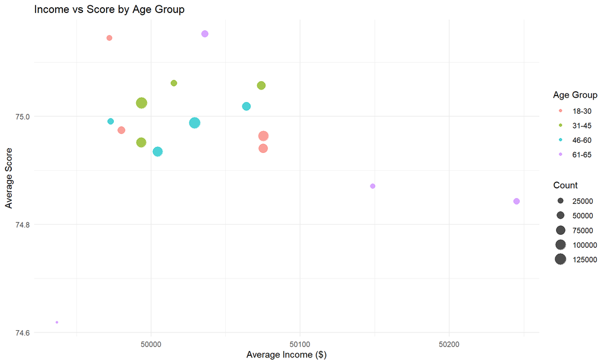

```r
# Scatter: income vs score by age group
p2 <- ggplot(viz_data, aes(x = Avg_Income, y = Avg_Score, color = Age_Group, size = Count)) +
  geom_point(alpha = 0.7) +
  labs(title = "Income vs Score by Age Group", x = "Average Income ($)", y = "Average Score",
       color = "Age Group", size = "Count") +
  theme_minimal()
print(p2)
```

# 4. Memory‑Efficient Data Wrangling with dplyr

**Why dplyr**: readable verb‑based grammar, good for medium to large datasets and complex pipelines.

## 4.1 Introduction to dplyr

- Core verbs: **filter**, **select**, **mutate**, **summarise**, **arrange**, **group_by**
- Great integration with the tidyverse and plotting libraries

```r
large_tbl <- as_tibble(large_data)
class(large_tbl)
```

```
## [1] "tbl_df"     "tbl"        "data.frame"
```

## 4.2 Basic dplyr Operations

```r
# 1) Filtering rows
high_edu <- large_tbl %>% filter(Education %in% c("Master", "PhD"))
list(n_advanced = nrow(high_edu), preview = head(high_edu, 3))
```

```
## $n_advanced
## [1] 300401
##
## $preview
## # A tibble: 3 × 5
##      ID   Age Income Education Score
##   <int> <int>  <dbl> <chr>     <dbl>
## 1     2    32  56808 Master     58.9
## 2     4    20  68092 Master     51.9
## 3     6    60  41529 Master     65.4
```

```r
# 2) Selecting columns
selected <- large_tbl %>% select(ID, Age, Income, Education)
list(cols = names(selected), preview = head(selected, 3))
```

```
## $cols
## [1] "ID"        "Age"       "Income"    "Education"
##
## $preview
## # A tibble: 3 × 4
##      ID   Age Income Education
##   <int> <int>  <dbl> <chr>
## 1     1    48  79566 Bachelor
## 2     2    32  56808 Master
## 3     3    31  49234 Bachelor
```

```r
# 3) Creating new columns
with_categories <- large_tbl %>%
  mutate(Performance = case_when(
    Score >= 90 ~ "Excellent",
    Score >= 80 ~ "Good",
    Score >= 70 ~ "Average",
    Score >= 60 ~ "Below Average",
    TRUE ~ "Poor"
  ))

as.data.frame(table(with_categories$Performance))
```

```
##            Var1   Freq
## 1       Average 199447
## 2 Below Average 199999
## 3     Excellent 201086
## 4          Good 199881
## 5          Poor 199587
```

```r
# 4) Sorting data
top_earners <- large_tbl %>% arrange(desc(Income)) %>% head(10)
top_earners
```

```
## # A tibble: 10 × 5
##        ID   Age Income Education   Score
##     <int> <int>  <dbl> <chr>       <dbl>
##  1 326580    47 124824 Master       61.2
##  2 577893    32 120946 Master       51.4
##  3  74371    29 118871 High School  95.8
##  4 232269    63 118533 Master       97.6
##  5 595621    48 117484 Bachelor     57.9
##  6 153372    47 117169 High School  61.5
##  7 384627    61 116998 Bachelor     58.1
##  8 670108    47 116380 High School  97
##  9 413639    39 115742 Master       88.1
## 10 610380    21 115481 Bachelor     51.4
```

## 4.3 Aggregation with dplyr

```r
# Simple summarisation
overall_summary <- large_tbl %>% summarise(
  Avg_Age = mean(Age), Avg_Income = mean(Income), Avg_Score = mean(Score), Total_Count = n())
overall_summary
```

```
## # A tibble: 1 × 4
##   Avg_Age Avg_Income Avg_Score Total_Count
##     <dbl>      <dbl>     <dbl>       <int>
## 1    41.5     50036.      75.0     1000000
```

```r
# Grouped aggregation
edu_summary <- large_tbl %>%
  group_by(Education) %>%
  summarise(Count = n(), Avg_Income = mean(Income), Median_Income = median(Income), Avg_Score = mean(Score), .groups = 'drop') %>%
  arrange(desc(Avg_Income))
edu_summary
```

```
## # A tibble: 4 × 5
##   Education    Count Avg_Income Median_Income Avg_Score
##   <chr>        <int>      <dbl>         <dbl>     <dbl>
## 1 Master      200094     50061.         50042      75.0
## 2 High School 299510     50049.         50067      74.9
## 3 Bachelor    400089     50028.         50047      75.0
## 4 PhD         100307     49986.         49954      75.0
```

```r
# Multiple grouping levels
detailed_summary <- large_tbl %>%
  mutate(Age_Group = cut(Age, breaks = c(18, 30, 45, 60, 65), labels = c("18-30", "31-45", "46-60", "61-65"))) %>%
  group_by(Education, Age_Group) %>%
  summarise(Count = n(), Avg_Income = mean(Income), Avg_Score = mean(Score), .groups = 'drop') %>%
  filter(Count > 1000) %>% arrange(Education, Age_Group)
head(detailed_summary, 10)
```

```
## # A tibble: 10 × 5
##    Education   Age_Group  Count Avg_Income Avg_Score
##    <chr>       <fct>      <int>      <dbl>     <dbl>
##  1 Bachelor    18-30     100139     50075.      75.0
##  2 Bachelor    31-45     125069     49994.      75.0
##  3 Bachelor    46-60     124852     50029.      75.0
##  4 Bachelor    61-65      41688     50036.      75.2
##  5 Bachelor    <NA>        8341     49900.      75.0
##  6 High School 18-30      75135     50075.      74.9
##  7 High School 31-45      93028     49993.      75.0
##  8 High School 46-60      93930     50005.      74.9
##  9 High School 61-65      31075     50245.      74.8
## 10 High School <NA>        6342     50241.      75.3
```

## 4.4 Chaining Operations with the Pipe Operator

**Pattern**: `data %>% filter(...) %>% mutate(...) %>% group_by(...) %>% summarise(...) %>% arrange(...)`

```r
analysis_result <- large_tbl %>%
  filter(Income > 30000, Score > 60) %>%
  mutate(
    Income_Group = case_when(Income < 50000 ~ "Low", Income < 80000 ~ "Medium", TRUE ~ "High"),
    Score_Group  = case_when(Score >= 90 ~ "A", Score >= 80 ~ "B", Score >= 70 ~ "C", Score >= 60 ~ "D", TRUE ~ "F")
  ) %>%
  group_by(Education, Income_Group, Score_Group) %>%
  summarise(Count = n(), Avg_Age = mean(Age), Min_Score = min(Score), Max_Score = max(Score), .groups = 'drop') %>%
  filter(Count > 100) %>% arrange(Education, desc(Count))

list(dimensions = dim(analysis_result), preview = head(analysis_result, 5))
```

```
## $dimensions
## [1] 48  7
##
## $preview
## # A tibble: 5 × 7
##   Education Income_Group Score_Group Count Avg_Age Min_Score Max_Score
##   <chr>     <chr>        <chr>       <int>   <dbl>     <dbl>     <dbl>
## 1 Bachelor  Medium       A           38746    41.5      90       100
## 2 Bachelor  Medium       B           38203    41.5      80        89.9
## 3 Bachelor  Medium       C           38147    41.5      70        79.9
## 4 Bachelor  Medium       D           37956    41.5      60.1      69.9
## 5 Bachelor  Low          A           32818    41.5      90       100
```

## 4.5 Memory Considerations with dplyr

```r
# Inefficient (creates multiple copies)
mem_before <- mem_used()
result1 <- filter(large_tbl, Income > 50000)
result2 <- select(result1, ID, Income)
result3 <- mutate(result2, Income_K = Income / 1000)
mem_after_inefficient <- mem_used()
rm(result1, result2, result3); gc()
```

```
##            used  (Mb) gc trigger  (Mb) max used  (Mb)
## Ncells  1610435  86.1    2478724 132.4  2478724 132.4
## Vcells 21965853 167.6   48431337 369.6 40274074 307.3
```

```r
# Efficient single pipeline
mem_before_efficient <- mem_used()
result_efficient <- large_tbl %>% filter(Income > 50000) %>% select(ID, Income) %>% mutate(Income_K = Income / 1000)
mem_after_efficient <- mem_used()

kable(
  tibble(
    Approach = c("Inefficient multi-copy", "Efficient pipeline"),
    Approx_KB = round(c(as.numeric(mem_after_inefficient - mem_before), as.numeric(mem_after_efficient - mem_before_efficient))/1024, 1)
  ), caption = "Approximate memory use: multi‑copy vs pipeline"
)
```

Approximate memory use: multi‑copy vs pipeline

| Approach | Approx_KB |
| --- | --- |
| Inefficient multi-copy | 19579 |
| Efficient pipeline | 9789 |

# 5. Performance Comparison: data.table vs dplyr

**Purpose**: Benchmark filtering and aggregation on a common 100K sample. Lower time = better.

## 5.1 Benchmarking Setup

```r
set.seed(123)
sample_size <- 100000
benchmark_sample <- large_data[sample(nrow(large_data), sample_size), ]
benchmark_dt  <- as.data.table(benchmark_sample)
benchmark_tbl <- as_tibble(benchmark_sample)
list(rows = sample_size, prepared = c("data.table", "tibble"))
```

```
## $rows
## [1] 100000
##
## $prepared
## [1] "data.table" "tibble"
```

## 5.2 Filtering Operation Comparison

```r
filter_benchmark <- microbenchmark(
  data.table = { nrow(benchmark_dt[Income > 60000 & Score > 75]) },
  dplyr      = { benchmark_tbl %>% filter(Income > 60000, Score > 75) %>% nrow() },
  times = 10
)
filter_benchmark
```

```
## Unit: milliseconds
##        expr   min    lq  mean median    uq   max neval cld
##  data.table 3.500 3.539 3.664  3.615 3.809 3.961    10  a
##       dplyr 4.511 4.581 4.704  4.670 4.763 4.975    10   b
```

```r
# Summary table
filter_summary <- as_tibble(filter_benchmark) %>%
  group_by(expr) %>% summarise(Mean_ms = mean(time/1e6), Median_ms = median(time/1e6), .groups = 'drop')
knitr::kable(filter_summary, caption = "Filtering performance (milliseconds)")
```

Filtering performance (milliseconds)

| expr | Mean_ms | Median_ms |
| --- | --- | --- |
| data.table | 3.664 | 3.615 |
| dplyr | 4.704 | 4.670 |

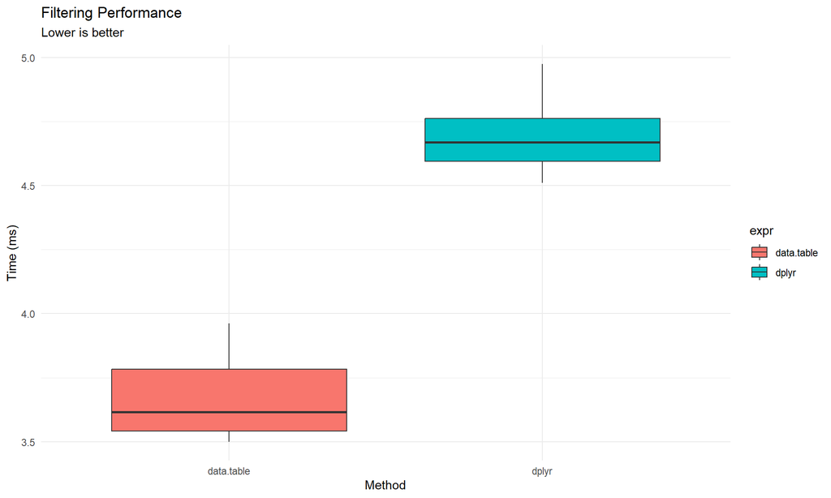

```r
# Visualise
p_filter <- ggplot(filter_benchmark, aes(x = expr, y = time/1e6, fill = expr)) +
  geom_boxplot() + labs(title = "Filtering Performance", subtitle = "Lower is better",
                        x = "Method", y = "Time (ms)") + theme_minimal()
print(p_filter)
```

## 5.3 Grouped Aggregation Comparison

```r
agg_benchmark <- microbenchmark(
  data.table = { benchmark_dt[, .(Avg_Income = mean(Income), Avg_Score = mean(Score), Count = .N), by = Education][] },
  dplyr      = { benchmark_tbl %>% group_by(Education) %>% summarise(Avg_Income = mean(Income), Avg_Score = mean(Score), Count = n(), .groups = 'drop') },
  times = 10
)
agg_benchmark
```

```
## Unit: milliseconds
##        expr   min    lq   mean median     uq    max neval cld
##  data.table 6.009 6.393  6.571  6.635  6.854  7.067    10  a
##       dplyr 9.168 9.316 10.247  9.944 11.137 12.176    10   b
```

```r
agg_summary <- as_tibble(agg_benchmark) %>% group_by(expr) %>%
  summarise(Mean_ms = mean(time/1e6), Median_ms = median(time/1e6), .groups = 'drop')
knitr::kable(agg_summary, caption = "Grouped aggregation performance (milliseconds)")
```

Grouped aggregation performance (milliseconds)

| expr | Mean_ms | Median_ms |
| --- | --- | --- |
| data.table | 6.571 | 6.635 |
| dplyr | 10.246 | 9.944 |

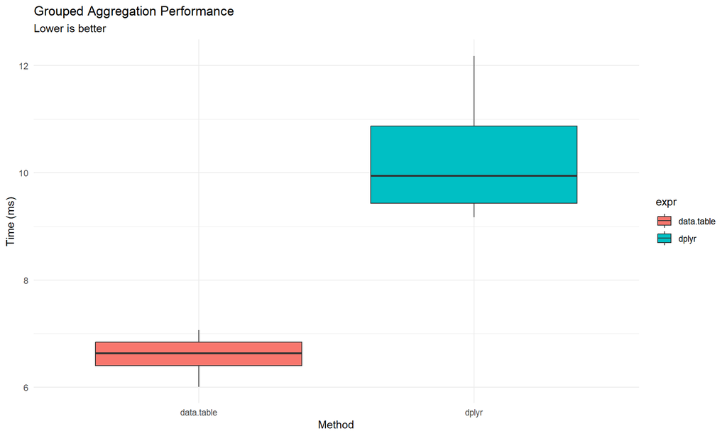

```r
p_agg <- ggplot(agg_benchmark, aes(x = expr, y = time/1e6, fill = expr)) +
  geom_boxplot() + labs(title = "Grouped Aggregation Performance", subtitle = "Lower is better",
                        x = "Method", y = "Time (ms)") + theme_minimal()
print(p_agg)
```

## 5.4 Complex Operation Comparison

```r
benchmark_dt[, Age_Group := cut(Age, breaks = c(18, 30, 45, 60, 65), labels = c("18-30", "31-45", "46-60", "61-65"))]
benchmark_tbl <- benchmark_tbl %>% mutate(Age_Group = cut(Age, breaks = c(18, 30, 45, 60, 65), labels = c("18-30", "31-45", "46-60", "61-65")))

complex_benchmark <- microbenchmark(
  data.table = {
    benchmark_dt[Income > 40000,
                 .(Avg_Income = mean(Income), Avg_Score = mean(Score), Count = .N),
                 by = .(Education, Age_Group)][Count > 100][order(-Avg_Income)]
  },
  dplyr = {
    benchmark_tbl %>% filter(Income > 40000) %>% group_by(Education, Age_Group) %>%
      summarise(Avg_Income = mean(Income), Avg_Score = mean(Score), Count = n(), .groups = 'drop') %>%
      filter(Count > 100) %>% arrange(desc(Avg_Income))
  }, times = 10
)
complex_benchmark
```

```
## Unit: milliseconds
##        expr    min     lq   mean median     uq    max neval cld
##  data.table  7.356  7.682  8.626  8.755  9.452  9.661    10  a
##       dplyr 17.557 18.017 18.457 18.530 18.776 19.224    10   b
```

```r
complex_summary <- as_tibble(complex_benchmark) %>% group_by(expr) %>%
  summarise(Mean_ms = mean(time/1e6), Median_ms = median(time/1e6), .groups = 'drop')
knitr::kable(complex_summary, caption = "Complex chain performance (milliseconds)")
```

Complex chain performance (milliseconds)

| expr | Mean_ms | Median_ms |
| --- | --- | --- |
| data.table | 8.626 | 8.755 |
| dplyr | 18.457 | 18.530 |

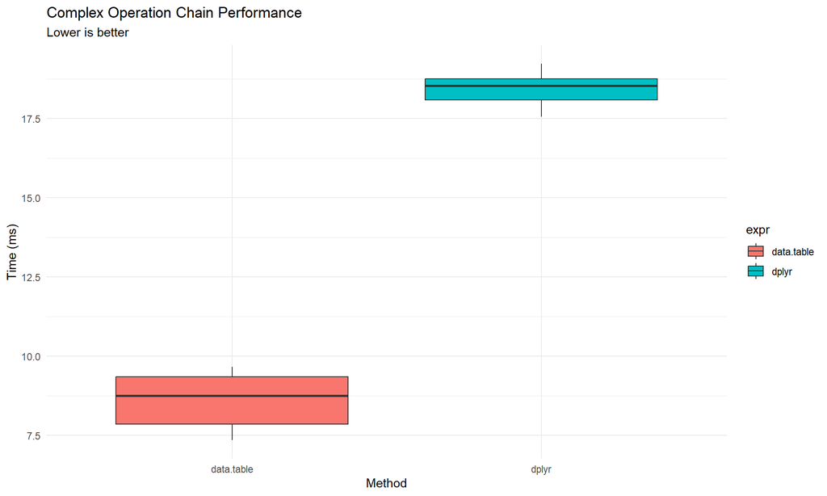

```r
p_complex <- ggplot(complex_benchmark, aes(x = expr, y = time/1e6, fill = expr)) +
  geom_boxplot() + labs(title = "Complex Operation Chain Performance", subtitle = "Lower is better",
                        x = "Method", y = "Time (ms)") + theme_minimal()
print(p_complex)
```

## 5.5 Memory Usage Comparison

```r
compare_memory_usage <- function() {
  results <- data.frame(Operation = character(), Method = character(), Memory_MB = numeric())
  # Filtering
  mem_before <- mem_used(); dt_result <- benchmark_dt[Income > 60000]; mem_after <- mem_used()
  results <- rbind(results, data.frame(Operation = "Filtering", Method = "data.table", Memory_MB = as.numeric(mem_after - mem_before)/1024^2))
  rm(dt_result); gc()
  mem_before <- mem_used(); dplyr_result <- benchmark_tbl %>% filter(Income > 60000); mem_after <- mem_used()
  results <- rbind(results, data.frame(Operation = "Filtering", Method = "dplyr", Memory_MB = as.numeric(mem_after - mem_before)/1024^2))
  rm(dplyr_result); gc()
  # Aggregation
  mem_before <- mem_used(); dt_result <- benchmark_dt[, .(Avg_Income = mean(Income)), by = Education]; mem_after <- mem_used()
  results <- rbind(results, data.frame(Operation = "Aggregation", Method = "data.table", Memory_MB = as.numeric(mem_after - mem_before)/1024^2))
  rm(dt_result); gc()
  mem_before <- mem_used(); dplyr_result <- benchmark_tbl %>% group_by(Education) %>% summarise(Avg_Income = mean(Income), .groups = 'drop'); mem_after <- mem_used()
  results <- rbind(results, data.frame(Operation = "Aggregation", Method = "dplyr", Memory_MB = as.numeric(mem_after - mem_before)/1024^2))
  results
}

memory_comparison <- compare_memory_usage()
knitr::kable(memory_comparison, caption = "Approximate memory usage by operation (MB)")
```

Approximate memory usage by operation (MB)

| Operation | Method | Memory_MB |
| --- | --- | --- |
| Filtering | data.table | 0.8816 |
| Filtering | dplyr | 0.8656 |
| Aggregation | data.table | 0.0488 |
| Aggregation | dplyr | 0.0006 |

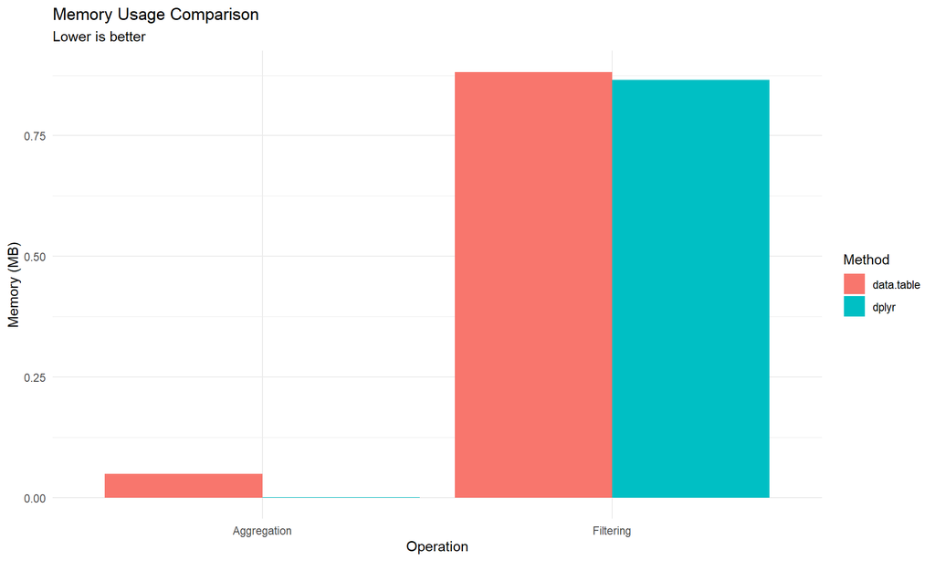

```r
p_memory <- ggplot(memory_comparison, aes(x = Operation, y = Memory_MB, fill = Method)) +
  geom_bar(stat = "identity", position = "dodge") +
  labs(title = "Memory Usage Comparison", subtitle = "Lower is better", x = "Operation", y = "Memory (MB)") +
  theme_minimal()
print(p_memory)
```

# 6. Working with Extremely Large Files

**Scenario**: Data doesn’t fit in RAM. Use **chunk processing**, **databases**, or **columnar formats**.

## 6.1 Chunk Processing with readr

**Instructions**: The following example writes a large CSV and then processes it in chunks of 100K rows. To avoid long knit times, the writing and chunk processing are set to `eval=FALSE`. Run interactively when needed.

```r
# Create large CSV file for demonstration
large_csv_file <- "data/large_demo_data.csv"
if (!dir.exists("data")) dir.create("data")
write.csv(large_data, large_csv_file, row.names = FALSE)
file_size <- file.info(large_csv_file)$size / 1024^2
cat(sprintf("Created %s (%.2f MB)\n", large_csv_file, file_size))

# Chunk processing function (100,000 rows per chunk)
process_file_in_chunks <- function(file_path, chunk_size = 100000) {
  chunk_count <- 0
  process_chunk <- function(chunk, pos) {
    chunk_count <<- chunk_count + 1
    chunk %>%
      filter(Income > 50000) %>%
      group_by(Education) %>%
      summarise(Avg_Income = mean(Income), Count = n(), .groups = 'drop') %>%
      mutate(Chunk = chunk_count)
  }
  readr::read_csv_chunked(
    file_path,
    callback = readr::DataFrameCallback$new(process_chunk),
    chunk_size = chunk_size,
    progress = readr::readr_progress()
  )
}

chunk_results <- process_file_in_chunks('data/large_demo_data.csv')
head(chunk_results)
```

## 6.2 Database Integration

**Why**: For very large datasets, a lightweight database like **SQLite** allows SQL queries and persistence beyond RAM.

```r
# Example workflow (run as needed)
# install.packages('RSQLite')
# library(RSQLite)
# conn <- dbConnect(SQLite(), 'data/large_data.db')
# dbWriteTable(conn, 'employee_data', large_data, overwrite = TRUE)
# result <- dbGetQuery(conn, "SELECT Education, AVG(Income) AS Avg_Income, COUNT(*) AS Count
#                              FROM employee_data WHERE Income > 50000
#                              GROUP BY Education ORDER BY Avg_Income DESC")
# dbDisconnect(conn)
```

## 6.3 Arrow Format for Large Data

**Apache Arrow/Parquet** offers fast, columnar storage and memory‑mapping.

```r
# install.packages('arrow')
# library(arrow)
# write_parquet(large_data, 'data/large_data.parquet')
# arrow_data <- read_parquet('data/large_data.parquet')
# result <- arrow_data %>% filter(Income > 50000) %>% group_by(Education) %>%
#   summarise(Avg_Income = mean(Income)) %>% collect()
# head(result)
```

# 7. Data Import and Export for Large Datasets

## 7.1 Comparing File Formats

**Overview**: CSV (portable but large/slow); RDS/RData (R‑native); Feather/Parquet (fast, multi‑language; needs packages).

```r
set.seed(123)
if (!dir.exists("data")) dir.create("data")
test_sample <- large_data[sample(nrow(large_data), 10000), ]

# CSV
csv_file <- "data/test_data.csv"; write.csv(test_sample, csv_file, row.names = FALSE)
csv_size <- file.info(csv_file)$size / 1024^2

# RDS
rds_file <- "data/test_data.rds"; saveRDS(test_sample, rds_file)
rds_size <- file.info(rds_file)$size / 1024^2

# RData
rdata_file <- "data/test_data.RData"; save(test_sample, file = rdata_file)
rdata_size <- file.info(rdata_file)$size / 1024^2

sizes <- tibble(Format = c("CSV", "RDS", "RData"), Size_MB = round(c(csv_size, rds_size, rdata_size), 2))
knitr::kable(sizes, caption = "File sizes by format (10K rows sample)")
```

File sizes by format (10K rows sample)

| Format | Size_MB |
| --- | --- |
| CSV | 0.31 |
| RDS | 0.13 |
| RData | 0.13 |

```r
# Optional: Feather (if available)
if (requireNamespace("feather", quietly = TRUE)) {
  feather_file <- "data/test_data.feather"
  feather::write_feather(test_sample, feather_file)
  feather_size <- round(file.info(feather_file)$size / 1024^2, 2)
  knitr::kable(tibble(Format = "Feather", Size_MB = feather_size), caption = "Feather size (optional)")
}
```

Feather size (optional)

| Format | Size_MB |
| --- | --- |
| Feather | 0.34 |

```r
# Cleanup
file.remove(csv_file, rds_file, rdata_file)
```

```
## [1] TRUE TRUE TRUE
```

```r
if (file.exists("data/test_data.feather")) file.remove("data/test_data.feather")
```

```
## [1] TRUE
```

## 7.2 Performance Comparison of Read/Write Operations

```r
io_data <- large_data[sample(nrow(large_data), 10000), ]

write_benchmark <- microbenchmark(
  CSV   = write.csv(io_data, "temp_csv.csv", row.names = FALSE),
  RDS   = saveRDS(io_data, "temp_rds.rds"),
  RData = save(io_data, file = "temp_rdata.RData"),
  times = 5
)
write_benchmark
```

```
## Unit: milliseconds
##   expr    min     lq   mean median     uq    max neval cld
##    CSV 111.58 117.93 116.91 118.02 118.04 118.96     5  a
##    RDS  33.43  33.51  34.03  34.14  34.18  34.91     5   b
##  RData  33.38  33.78  33.83  33.95  34.00  34.02     5   b
```

```r
read_benchmark <- microbenchmark(
  CSV   = read.csv("temp_csv.csv"),
  RDS   = readRDS("temp_rds.rds"),
  RData = {load("temp_rdata.RData"); io_data},
  times = 5
)
read_benchmark
```

```
## Unit: milliseconds
##   expr   min     lq   mean median     uq    max neval cld
##    CSV 22.40 22.464 23.333 23.005 23.010 25.782     5  a
##    RDS  4.96  5.183  5.166  5.194  5.227  5.263     5   b
##  RData  5.27  5.306  5.373  5.337  5.439  5.514     5   b
```

```r
file.remove(c("temp_csv.csv", "temp_rds.rds", "temp_rdata.RData"))
```

```
## [1] TRUE TRUE TRUE
```

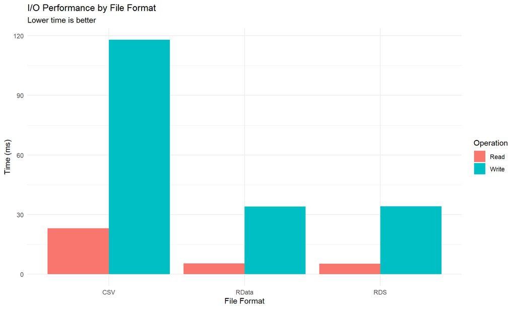

```r
write_times <- tibble(
  Format = c("CSV", "RDS", "RData"), Operation = "Write",
  Time_ms = c(median(write_benchmark[write_benchmark$expr == "CSV", "time"])/1e6,
              median(write_benchmark[write_benchmark$expr == "RDS", "time"])/1e6,
              median(write_benchmark[write_benchmark$expr == "RData", "time"])/1e6)
)
read_times <- tibble(
  Format = c("CSV", "RDS", "RData"), Operation = "Read",
  Time_ms = c(median(read_benchmark[read_benchmark$expr == "CSV", "time"])/1e6,
              median(read_benchmark[read_benchmark$expr == "RDS", "time"])/1e6,
              median(read_benchmark[read_benchmark$expr == "RData", "time"])/1e6)
)
io_times <- rbind(write_times, read_times)

p_io <- ggplot(io_times, aes(x = Format, y = Time_ms, fill = Operation)) +
  geom_bar(stat = "identity", position = "dodge") +
  labs(title = "I/O Performance by File Format", subtitle = "Lower time is better",
       x = "File Format", y = "Time (ms)") + theme_minimal()
print(p_io)
```

## 7.3 Efficient Data Import Strategies

**Strategies** 1) **Read only necessary columns** (e.g., `fread(select=...)`)  
2) **Specify column types** upfront to speed parsing  
3) **Sample or skip rows** for quick inspection  
4) **Show progress bars** on long imports  
5) Use **parallel reading** when supported

```r
# Example: Efficient CSV reading with data.table
library(data.table)
large_data <- fread('data/large_demo_data.csv',
                    select = c('ID', 'Age', 'Income', 'Score'),
                    nrows = 500000,  # Limit rows if needed
                    showProgress = TRUE)
```

# 8. Parallel Processing for Large Datasets

## 8.1 Introduction to Parallel Processing

- Parallelism divides work across multiple CPU cores
- Best for **CPU‑bound**, independent tasks (not I/O‑bound)
- Packages: **parallel** (base), **foreach**/**doParallel**, **future**

## 8.2 Simple Parallel Processing Example

```r
if (require(parallel, quietly = TRUE)) {
  set.seed(123)
  demo_data <- large_data[sample(nrow(large_data), 100000), ]

  process_chunk <- function(chunk_data) {
    data.frame(Avg_Income = mean(chunk_data$Income), Avg_Score = mean(chunk_data$Score), Count = nrow(chunk_data))
  }

  # Sequential
  start_seq <- Sys.time()
  chunks <- split(demo_data, cut(seq_len(nrow(demo_data)), 4, labels = FALSE))
  seq_results <- lapply(chunks, process_chunk)
  seq_final <- do.call(rbind, seq_results)
  seq_time <- as.numeric(Sys.time() - start_seq)

  # Parallel (2 cores)
  start_par <- Sys.time(); cl <- makeCluster(2)
  clusterExport(cl, "process_chunk")
  par_results <- parLapply(cl, chunks, process_chunk)
  stopCluster(cl)
  par_final <- do.call(rbind, par_results)
  par_time <- as.numeric(Sys.time() - start_par)

  kable(tibble(Method = c("Sequential", "Parallel (2 cores)"), Seconds = round(c(seq_time, par_time), 2),
               Speedup = c(1, round(seq_time/par_time, 2))), caption = "Sequential vs Parallel timing")
} else {
  "Package 'parallel' not available (install if needed)."
}
```

Sequential vs Parallel timing

| Method | Seconds | Speedup |
| --- | --- | --- |
| Sequential | 0.02 | 1.00 |
| Parallel (2 cores) | 0.34 | 0.06 |

## 8.3 Parallel Processing with foreach

```r
if (require(doParallel, quietly = TRUE) && require(foreach, quietly = TRUE)) {
  set.seed(123)
  sample_income <- large_data$Income[1:10000]

  # Sequential bootstrap
  start_seq <- Sys.time()
  seq_bootstrap <- replicate(1000, mean(sample(sample_income, 1000, replace = TRUE)))
  seq_time <- as.numeric(Sys.time() - start_seq)

  # Parallel bootstrap (2 cores)
  cl <- makeCluster(2); registerDoParallel(cl)
  start_par <- Sys.time()
  par_bootstrap <- foreach(i = 1:1000, .combine = c) %dopar% {
    mean(sample(sample_income, 1000, replace = TRUE))
  }
  stopCluster(cl)
  par_time <- as.numeric(Sys.time() - start_par)

  kable(tibble(Method = c("Sequential", "Parallel (2 cores)"), Seconds = round(c(seq_time, par_time), 2),
               Speedup = c(1, round(seq_time/par_time, 2))), caption = "Bootstrap timing: sequential vs parallel")
} else {
  "Install 'doParallel' and 'foreach' to run this example."
}
```

Bootstrap timing: sequential vs parallel

| Method | Seconds | Speedup |
| --- | --- | --- |
| Sequential | 0.10 | 1.00 |
| Parallel (2 cores) | 0.42 | 0.24 |

## 8.4 When Not to Use Parallel Processing

- **Small datasets**: overhead outweighs benefits
- **I/O‑bound** tasks: threads wait on disk/network
- **Tight memory**: each worker may duplicate data
- **Dependent steps**: cannot parallelise effectively
- **Resource contention**: many workers can slow the system

> **Best practice**: Always test sequential vs parallel; monitor memory; consider the **future** framework for flexible backends.

# 9. Best Practices and Tips for Large Datasets

## 9.1 Memory Management Strategies

- Use appropriate types (integers, factors); specify types on import
- Remove unused data (`df$col <- NULL`; `rm()` + `gc()`)
- Process in chunks (`readr::read_csv_chunked()`); write intermediates
- Monitor usage (`pryr::mem_used()`, `object.size()`); set limits (Windows)
- Packages for big data: **data.table**, **Matrix** (sparse), **bigmemory**, **ff**

## 9.2 Performance Optimization

- Choose the right tool: **data.table** for >1M rows; **dplyr** for readable pipelines
- Avoid unnecessary copies; prefer **in‑place** (`:=`)
- Optimise I/O: **fst**, **feather**, **arrow**; read only needed columns
- Parallelise CPU‑bound parts (leave one core free); benchmark with `microbenchmark`
- Profile hot spots (`profvis::profvis()`, `system.time()`, RStudio profiler)

## 9.3 Data Storage Strategies

Data storage formats: pros and cons

| Format | Best_For | Pros | Cons |
| --- | --- | --- | --- |
| CSV | Data exchange, human reading | Universal, readable | Slow, large files |
| RDS | R objects, fast loading | Preserves objects, fast read | R-specific, binary |
| RData | Multiple R objects | Save multiple objects | Cannot inspect without loading |
| Feather | Fast I/O, language-agnostic | Very fast, multi-language | Larger file size |
| FST | Large datasets, fast access | Extremely fast, compression | Less universal |
| Parquet | Columnar storage, big data | Efficient queries, compression | Requires ‘arrow’ |
| SQLite | Relational data, querying | SQL, concurrent access | DB setup needed |

**Compression**: `saveRDS(..., compress=TRUE)`; gzip CSVs; `fst` compression levels  
**Partitioning**: split by time/category; directory partitioning; DB partitioning  
**Versioning**: use Git‑LFS; maintain metadata, lineage, and dictionaries

## 9.4 Workflow Recommendations

- **Project structure**: use RStudio Projects; folders: `data/`, `scripts/`, `output/`, `figs/`
- **Reproducibility**: set seeds; manage packages with **renv**; use R Markdown
- **Monitoring**: show progress bars; log steps; checkpoint long workflows
- **Error handling**: `tryCatch()`; validate early; test on small samples first
- **Documentation**: comment why (not just what); keep data dictionaries and READMEs

# 10. Decision Guide: When to Use What

Based on our comparisons and experiences, here’s a practical guide to choosing the right tool for your large data tasks.

## 10.1 Library Selection Guide

Selecting the appropriate library depends on your specific needs

Decision Guide for Choosing Between dplyr and data.table

| Scenario | Recommended.Tool | Reason |
| --- | --- | --- |
| Dataset size < 1 million rows | dplyr (or data.table) | Readable and sufficiently fast |
| Dataset size 1–10 million rows | data.table (or dplyr with care) | Performance advantages become noticeable |
| Dataset size > 10 million rows | data.table, chunking, or databases | Requires memory-efficient strategies |
| Need maximum speed for aggregation | data.table | Highly optimized C-level aggregation |
| Prioritize code readability | dplyr | Verb-based syntax is intuitive |
| Complex data manipulation pipelines | dplyr with pipes | Pipelines remain easy to understand |
| Memory is a tight constraint | data.table (in-place ops) | Avoids unnecessary data copies |
| Need to join/merge large datasets | data.table with keys | Fast binary-search joins |
| Working with time series data | data.table | Optimized rolling and time-based ops |
| Interactive data exploration | dplyr or data.table | Depends on speed vs readability needs |

### KEY TAKEAWAYS

- For most analytical tasks under 1M rows, dplyr is an excellent choice due to its readability and ease of use.
- For larger datasets or performance-critical workloads, data.table is generally the better option because of its speed and memory efficiency.
- A hybrid approach often works best—use data.table for heavy data processing and dplyr for clear, expressive presentation.
- Always benchmark and test with your actual data and operations before choosing a tool.

## 10.2 Function Comparison Table

```
## === FUNCTION COMPARISON: data.table vs dplyr ===
```

Function Comparison: data.table vs dplyr

| Operation | data.table | dplyr | Notes |
| --- | --- | --- | --- |
| Filter rows | DT[condition] | filter(condition) | Similar syntax, both fast |
| Select columns | DT[, .(col1, col2)] | select(col1, col2) | data.table uses .() notation |
| Create new column | DT[, new_col := expression] | mutate(new_col = expression) | data.table modifies in place (memory efficient) |
| Group by and summarize | DT[, .(mean = mean(x)), by = group] | group_by(group) %>% summarise(mean = mean(x)) | data.table significantly faster for large groups |
| Sort data | DT[order(col)] | arrange(col) | Both efficient, data.table slightly faster |
| Join/merge datasets | DT1[DT2, on = ‘key’] | left_join(DT1, DT2, by = ‘key’) | data.table much faster with keys set |
| Update values | DT[condition, col := value] | mutate(col = ifelse(condition, value, col)) | data.table more memory efficient |
| Count rows by group | DT[, .N, by = group] | group_by(group) %>% tally() | Both similar, .N is data.table shorthand |
| Remove duplicates | unique(DT) | distinct() | Both efficient |
| Reshape data | dcast/melt from data.table | pivot_wider/pivot_longer from tidyr | data.table’s melt/dcast often faster |

Notes: - data.table: Generally 2–10× faster for large datasets - dplyr: More consistent syntax, easier to read - Memory: data.table uses less memory due to in-place operations - Learning curve: dplyr is easier to learn, while data.table is more concise

## 10.3 Practical Recommendations

Based on extensive testing and real-world usage:

### 1. FOR BEGINNERS OR TEAMS

- Start with dplyr for its intuitive syntax
- Switch to data.table when performance becomes an issue
- Document which operations are performance-critical
- Create wrapper functions if needed for consistency

### 2. FOR PRODUCTION SYSTEMS

- Use data.table for backend data processing
- Consider databases for data > RAM size
- Implement proper error handling and logging
- Monitor memory usage and performance

### 3. FOR RESEARCH/EXPLORATION

- Use dplyr for interactive exploration
- Switch to data.table for final analysis if needed
- Create reproducible scripts with both approaches
- Benchmark to justify tool choices

### 4. HYBRID APPROACH

Many successful teams use: - data.table for ETL and heavy processing - dplyr for analysis and reporting - Specialized packages for specific tasks - Clear guidelines on when to use each

### 5. MIGRATION STRATEGY

If moving from dplyr to data.table: 1. Profile to identify bottlenecks 2. Convert only critical sections first 3. Test thoroughly for correctness 4. Document the performance gains

## 10.4 Summary Table: Key Functions for Big Data

```
## === SUMMARY: KEY FUNCTIONS FOR BIG DATA ===
```

```
## ### ESSENTIAL FUNCTIONS FOR LARGE DATASETS
```

Recommended functions and packages for efficient large data processing

| Task | Recommended_Function | Package | When_To_Use |
| --- | --- | --- | --- |
| Fast data reading | data.table::fread() | data.table | Reading CSV files > 100MB |
| Memory-efficient filtering | data.table filtering with i | data.table | Filtering large datasets frequently |
| Quick aggregation | data.table aggregation with by | data.table | Grouped operations on >1M rows |
| Fast joins/merges | data.table joins with on and keys | data.table | Merging large datasets |
| Large file writing | fst::write_fst() or arrow::write_parquet() | fst or arrow | Saving processed results |
| Chunk processing | readr::read_csv_chunked() | readr | Files too large for memory |
| Memory monitoring | pryr::mem_used() and object.size() | pryr | Monitoring memory consumption |
| Progress tracking | progress::progress_bar or built-in showProgress | progress or data.table | Long-running operations |
| Parallel processing | future::plan() and future.apply | future | CPU-intensive tasks |
| Data compression | saveRDS(compress = TRUE) | base R | Reducing storage footprint |

### QUICK REFERENCE

- For speed: data.table
- For memory: data.table with in-place operations
- For readability: dplyr
- For huge files: Chunk processing or databases
- For parallel: future package
- For storage: fst or arrow format

# 11. Additional Resources and Next Steps

To deepen your understanding of handling large datasets in R:

## RESOURCES & REFERENCES

### 1. Official Documentation

- **data.table**: https://rdatatable.gitlab.io/data.table/
- **dplyr**: https://dplyr.tidyverse.org/
- **readr**: https://readr.tidyverse.org/
- **arrow**: https://arrow.apache.org/docs/r/

### 2. Books

- *R for Data Science* by Hadley Wickham & Garrett Grolemund
- *Efficient R Programming* by Colin Gillespie & Robin Lovelace
- *Advanced R* by Hadley Wickham
- *The data.table Package* by Matt Dowle & Arun Srinivasan

### 3. Online Courses

- DataCamp: *Working with Large Datasets in R*
- Coursera: *Big Data Analysis with R and Hadoop*
- Udemy: *R Programming for Data Science*
- EdX: *Data Science and Machine Learning Essentials*

### 4. Community Resources

- RStudio Community: community.rstudio.com
- Stack Overflow: stackoverflow.com/questions/tagged/r
- GitHub: github.com/topics/r
- R-bloggers: r-bloggers.com

### 5. Practice Datasets

- Kaggle: kaggle.com/datasets
- UCI Machine Learning Repository
- Google Dataset Search
- R dataset packages (e.g., *nycflights13*, *babynames*, etc.)

## 11.2 Practice Exercises

Apply what you’ve learned with these exercises:

## PRACTICAL EXERCISES FOR LARGE DATA ANALYSIS

### EXERCISE 1: BASIC OPERATIONS

- Load the large dataset using both `fread()` and `read_csv()`
- Compare loading times and memory usage
- Filter for Age > 40 and Income > 60000 using both data.table and dplyr
- Compare performance using `microbenchmark`

### EXERCISE 2: AGGREGATION TASKS

- Calculate average income by education level using both tools
- Find the top 3 age groups by average score
- Create a summary table with count, mean, and median by education
- Visualize the results using `ggplot2`

### EXERCISE 3: MEMORY MANAGEMENT

- Monitor memory usage during a complex operation chain
- Implement the same operation using in-place modifications
- Compare memory usage before and after garbage collection
- Write a function that cleans up intermediate objects

### EXERCISE 4: LARGE FILE PROCESSING

- Split the large dataset into multiple CSV files
- Write a function to process each file independently
- Combine results from all files
- Implement progress reporting for the processing

### EXERCISE 5: PERFORMANCE OPTIMIZATION

- Identify the slowest part of your analysis pipeline
- Try three different optimizations for that part
- Measure the performance improvement
- Document your findings and recommendations

## 11.3 Common Pitfalls and Solutions

Avoid these common mistakes when working with large datasets:

### 1. OUT OF MEMORY ERRORS

**Problem:** “Cannot allocate vector of size…”  
**Solution:** - Process data in chunks - Remove unused objects with `rm()` - Use `gc()` to force garbage collection - Increase memory limit (if possible) - Use disk-based storage (`ff`, `bigmemory`)

### 2. SLOW PERFORMANCE

**Problem:** Operations take too long  
**Solution:** - Use `data.table` instead of `data.frame` - Avoid loops; use vectorized operations - Set keys for frequent joins/filters - Use appropriate data types - Consider parallel processing

### 3. INCORRECT RESULTS

**Problem:** Results don’t match expectations  
**Solution:** - Test with a small sample first - Check for `NA`/`NULL` values - Verify data types and conversions - Use `summary()` and `str()` for verification - Implement data validation checks

### 4. REPRODUCIBILITY ISSUES

**Problem:** Code works on one machine but not another  
**Solution:** - Use `set.seed()` for random operations - Document package versions with `sessionInfo()` - Use `renv` for package management - Specify absolute file paths or use the `here()` package - Create self-contained analysis scripts

### 5. DATA IMPORT PROBLEMS

**Problem:** Can’t read large files  
**Solution:** - Use `fread()` for CSV files - Specify column types in advance - Read only needed columns - Use chunked reading for very large files - Convert to efficient format (`fst`, `parquet`)

**This material is part of the training program by The National Centre for Research Methods © [NCRM](https://www.ncrm.ac.uk/about/) authored by [Dr Somnath Chaudhuri](https://www.southampton.ac.uk/people/65ctq8/doctor-somnath-chaudhuri) (University of Southampton). Content is under a CC BY‑style permissive license and can be freely used for educational purposes with proper attribution.**